# STAT400 Final R-Project

Amelia Hsu (117956023), Alexandra O’Keeffe (117245790), Joselyn Rodriguez (118294025), Muhammad Umar (116449489), Mariel Viray (117100891

4/23/2022

## Introduction

COVID-19 is a coronavirus that was first identified in Wuhan, China in December 2019. Since its first appearance, COVID-19 has rapidly spread across the world, causing a global pandemic that has now lasted for several years (“CDC Museum COVID-19 Timeline”). To reduce the virus’ spread, countries began enforcing regulations such as social distancing and mask wearing. But, perhaps the most important countermeasure is the vaccine that was rapidly developed and distributed within the year after the first cases. Soon after development, the vaccine was administered to civilians across the world. While this was a great step forward, there are challenges that arose, thus allowing for the pandemic to continue. These issues are the imbalances of power — which meant that early distribution of vaccines was limited to only the richest countries — and the rise of new, more contagious variants, like the Omicron and Delta variants. While the end of the pandemic-era of COVID-19 seems to be in our near future, its effects are ever present and will likely be long-lasting, continuing to permeate our daily lives for the foreseeable future (Susskind). In order to better understand the behavior of the virus and its impact around the world, we will be exploring how the virus spread by using the number of cases and the number of deaths across different countries. We will see how these numbers change before and after the release of the vaccine in these countries to determine the role vaccine distribution has had on the impact of COVID-19 across the world.

Given the difference in times of release of vaccines and vaccine development across the world as well as socio-political reception of regulation, the spread and impact of the virus is expected to differ according to several factors (“Tracking Coronavirus Vaccinations Around the World”).

In this exploratory analysis, we aim to explore the following questions: What is the relationship between cases and deaths due to COVID-19 in countries across continents? What about across the United States? Finally, what effect did the release of the vaccine (to the general public) have on cases and deaths across the United States and the World? Following this analysis, we will provide a brief conclusion that discusses what insight we can draw on the impact of the pandemic and consideration for what this might mean for future pandemics.

## Data Exploration and Analysis

### *Relationship between the number of COVID-19 cases and deaths*

The first idea we planned to explore in this study was that of the relationship between cases and deaths due to COVID-19. We’ll begin by taking a look at cases and deaths in different countries in the world. The following plot illustrates the total number of cases of COVID-19 and deaths over time.

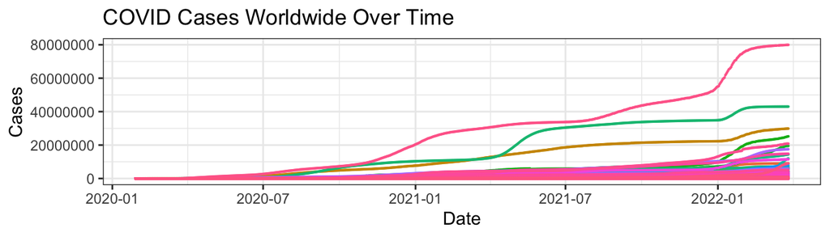

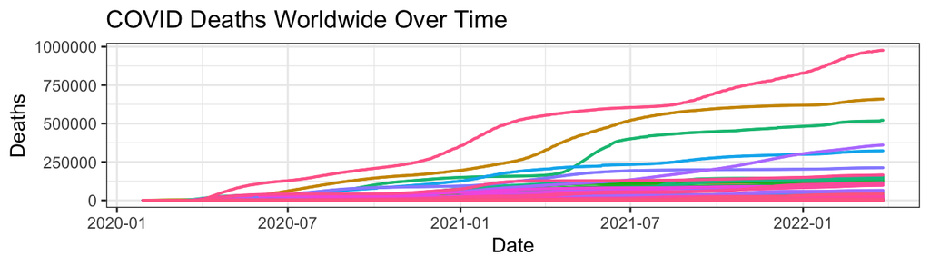

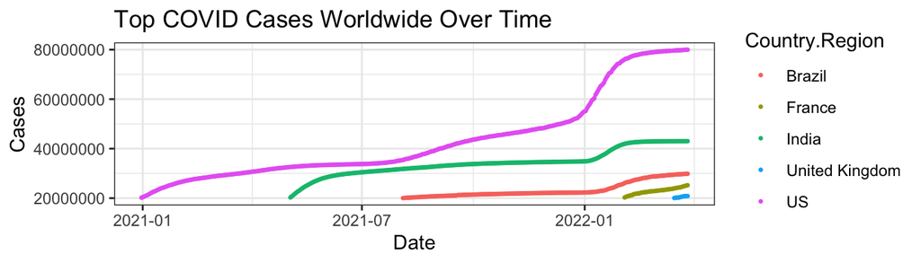

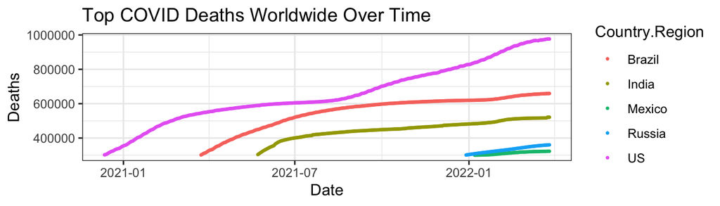

Taking a closer look at the daily rates of cases and deaths, we see that the number of daily cases is not linear, but rather comes in waves with the most recent peak in the winter of 2022. Overall, the US (the pink line) is leading in terms of number of cases, but the graph’s overall trend shows that many countries across the world each experience their own peaks throughout the year. Interestingly, the pattern of deaths doesn’t seem to follow quite the same pattern as the number of cases. While there are also peaks in deaths throughout the year, the variance in the days is much wider, suggesting that there are more deaths spread out before and after we see the peaks in the number of cases (however, note the values of the y-axis indicate there are much fewer deaths than cases). This may be suggestive of longer term effects of COVID-19.

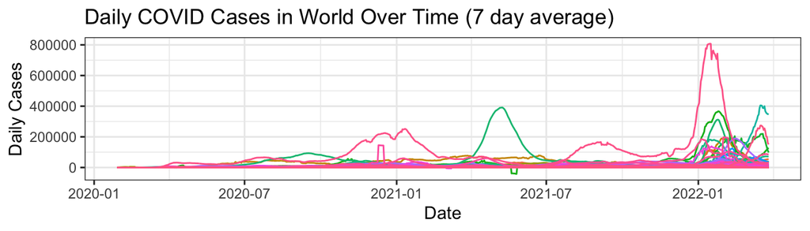

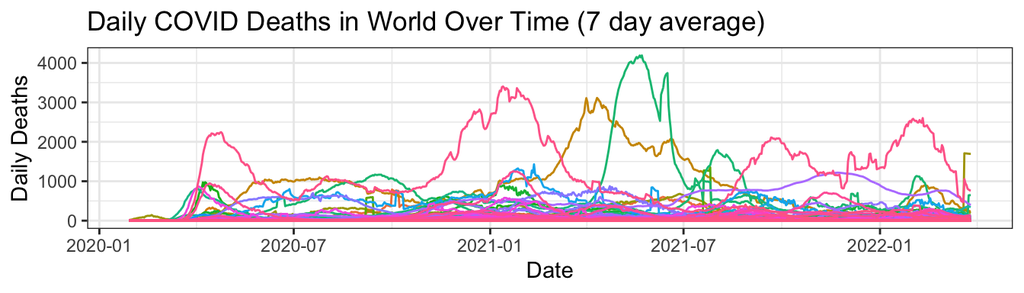

Now, taking a closer look at just the United States, we see a similar trend to the rest of the world. Importantly, we can now see how much of the trend worldwide was due to the United States alone.

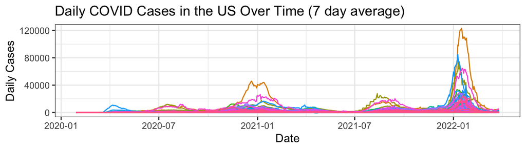

[figure not shown]

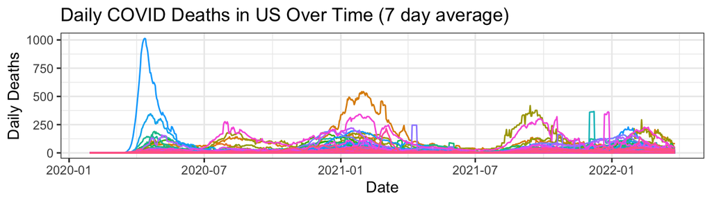

This figure shows the progression of daily COVID cases over time in the United States. It illustrates the waves of cases we’ve been seeing throughout the pandemic, particularly during the winter months in January 2021 and January 2022. Importantly, we can see that the number of cases in the current year, 2022, are actually higher than those from last year. This may be indicative of the highly contagious variants that have been making their way through the United States during this time. If this is true, then we would also expect to see fewer deaths associated with this peak, given that new variants such as Omicron, while more infectious, are generally milder strains of COVID-19 (“What You Need to Know About Variants”). Examining the daily deaths, we see the number of deaths has in fact dropped from 2021.

### *Exploration of Vaccine Efficacy*

To look at the effect of vaccination (or specifically, vaccine release) on deaths related to COVID-19, we’ve separated out three countries to take a closer look at: The United States, China, and India.

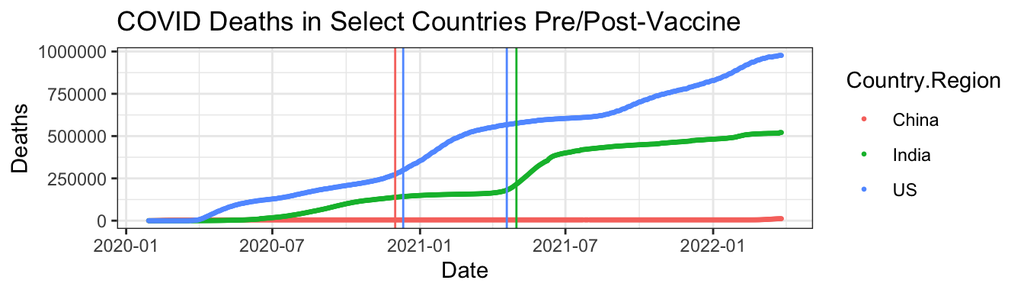

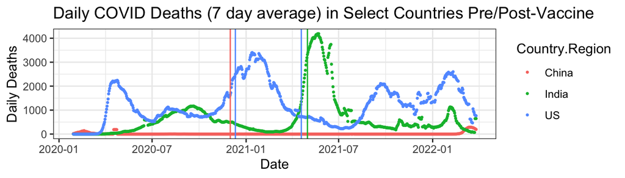

## Future Work

The present work explored the number of cases of COVID-19 and related deaths in the last two years. The dataset that was utilized was the COVID-19 Data Repository by the Center for Systems Science and Engineering (CSSE) at Johns Hopkins University (“COVID-19 Data Repository”). While informative regarding total cases and deaths, this dataset did not allow exploration of other possible contributing factors including demographic information, vaccination percentages, and infrastructure. Future explorations that include this information may be able to provide more insight into the progression of the pandemic before and after vaccine rollout and the effectiveness of different responses to the pandemic throughout the world.

## Works Cited

AJMC Staff. “A Timeline of COVID-19 Developments in 2020.” AJMC, 1 Jan. 2021, www.ajmc.com/view/a-timeline-of-covid19-developments-in-2020. Accessed 2 May 2022.

“CDC Museum COVID-19 Timeline.” Centers for Disease Control and Prevention, 5 Jan. 2022, https://www.cdc.gov/museum/timeline/covid19.html. Accessed 30 Aug. 2022.

“COVID-19 Data Repository by the Center for Systems Science and Engineering (CSSE) at Johns Hopkins University.” Johns Hopkins University Center for Systems Science and Engineering, 28 Mar. 2022. https://github.com/CSSEGISandData/COVID-19/tree/ 07b1f98abad77a702ebebd28c1a04ba9b82867bd. Accessed 28 Aug. 2022.

Crist, Carolyn. “All U.S. Adults Eligible for COVID-19 Vaccines.” WebMD, 20 Apr. 2021, www.webmd.com/vaccines/covid-19-vaccine/news/20210420/all-us-adults-eligible-covid-vaccines#:%7E:text=April%2020%2C%202021%20%2D%2D%20All,19%20deadline%20to%20open%20eligibility. Accessed 2 May 2022.

Holder, Josh. “Tracking Coronavirus Vaccinations Around the World.” The New York Times, 2 May 2022, https://www.nytimes.com/interactive/2021/world/covid-vaccinations- tracker.html. Accessed 2 May 2022.

Katella, Kathy. “5 Things To Know About the Delta Variant.” Yale Medicine, 1 Mar. 2022 https://www.yalemedicine.org/news/5-things-to-know-delta-variant-covid. Accessed 2 May 2022.

Susskind, Daniel, et al. “How Will the World Be Different After COVID-19.” International Monetary Fund, Finance and Development, June 2020, www.imf.org/external/pubs/ ft/fandd/2020/06/how-will-the-world-be-different-after-COVID-19.htm. Accessed 2 May 2022.

“Weekly epidemiological update on COVID-19 - 29 March 2022.” World Health Organization, 29 Mar. 2022. www.who.int/publications/m/item/weekly-epidemiological- update-on-covid-19—29-march-2022. Accessed 2 May 2022.

“What You Need to Know About Variants.” Centers for Disease Control and Prevention, 26 Apr. 2022. https://www.cdc.gov/coronavirus/2019-ncov/variants/about-variants.html#:~:text= New%20variants%20of%20the%20virus,causes%20COVID%2D19. Accessed 2 May 2022.

Wikipedia contributors. “COVID-19 Vaccination in India.” Wikipedia, 2 May 2022, en.wikipedia.org/wiki/COVID-19_vaccination_in_India. Accessed 2 May 2022.

Zheng, Wen, et al. “COVID-19 Vaccination Program in the Mainland of China: A Subnational Descriptive Analysis on Target Population Size and Current Progress - Infectious Diseases of Poverty.” BioMed Central, Springer Nature, 15 Oct. 2021, idpjournal.biomedcentral.com/articles/10.1186/s40249-021-00909-1#:%7E:text=In%20the%20mainland%20of%20China%2C%20COVID%2D19%20vaccination%20program%20is,population. Accessed 2 May 2022.